# Lasso Simulation Study

Anurag Nepal

2026-10-03

# Background

I wanted to know how well lasso actually recovers the true variables when the dimension grows. Theory says lasso can select correctly under the right conditions, but I wanted to see the trade-offs myself: how the choice between the minimum-lambda and 1se-lambda tuning rules plays out across sample sizes, dimensions, signal strengths, and predictor correlations.

# Setup

No real data here. I simulated it: 5 true signals out of p predictors, with AR(1) correlation structure between predictors, Gaussian noise, and a separate 500-row test set per replication. The full grid is sample size n in {50, 100, 200}, dimension p in {200, 400, 600}, signal strength A in {0.5, 1.0, 1.5}, and predictor correlation rho in {0, 0.5, 0.8}, with 100 replications per setting run in parallel. Each setting uses its own seed so the whole study is reproducible.

# Method

## The simulation

For each setting I draw training and test data from a multivariate normal with Toeplitz covariance, set the first five coefficients to alternating +A/-A, and fit lasso via `cv.glmnet` with 10-fold CV. I record both the `lambda.min` and `lambda.1se` solutions. Each fit is scored on selection metrics, sensitivity, false positive rate, precision, exact recovery of the true support, and estimation error, plus test MSE on the held-out 500 rows. Results are averaged over the 100 replications and written to `lasso_simulation_results.csv`, which is in this repo.

```r
library(glmnet)
library(MASS)
library(dplyr)
library(tidyr)
library(foreach)
library(doParallel)

# Selection metrics for one fitted coefficient vector.
# Compares the estimated support {j : beta_hat[j] != 0} against the true
# support. Returns c(sensitivity, fpr, precision, exact_recovery, est_error).
calculate_metrics <- function(beta_true, beta_hat) {
  p <- length(beta_true)
  true_support <- which(beta_true != 0)
  est_support <- which(beta_hat != 0)
  tp <- length(intersect(true_support, est_support))
  fp <- length(setdiff(est_support, true_support))
  sensitivity <- tp / length(true_support)
  fpr <- fp / (p - length(true_support))
  precision <- if (length(est_support) == 0) 0 else tp / length(est_support)
  exact_recovery <- as.numeric(setequal(true_support, est_support))
  est_error <- sqrt(sum((beta_hat - beta_true)^2))
  c(sensitivity, fpr, precision, exact_recovery, est_error)
}

n_vals <- c(50, 100, 200)
p_vals <- c(200, 400, 600)
A_vals <- c(0.5, 1.0, 1.5)
rho_vals <- c(0, 0.5, 0.8)
n_reps <- 100
test_n <- 500

settings <- expand.grid(n = n_vals, p = p_vals, A = A_vals, rho = rho_vals)
total_settings <- nrow(settings)

# Setup Parallel
num_cores <- detectCores() - 1
cl <- makeCluster(num_cores)
registerDoParallel(cl)

cat("Starting parallel simulation on", num_cores, "cores...\n")

#parallel computing for faster processing
final_results <- foreach(i = 1:total_settings,
                         .packages = c("glmnet", "MASS"),
                         .combine = rbind) %dopar% {
  #set a single seed for each run so that the results are reproducable
  set.seed(748 + i)

  n <- settings$n[i]
  p <- settings$p[i]
  A <- settings$A[i]
  rho <- settings$rho[i]

  beta_true <- rep(0, p)
  beta_true[1:5] <- c(A, -A, A, -A, A)

  first_row <- rho^(0:(p-1))
  Sigma <- toeplitz(first_row)

  metrics_min <- matrix(0, nrow = n_reps, ncol = 6)
  metrics_1se <- matrix(0, nrow = n_reps, ncol = 6)

  for (rep in 1:n_reps) {
    X_train <- mvrnorm(n, mu = rep(0, p), Sigma = Sigma)
    eps_train <- rnorm(n, mean = 0, sd = 1)
    Y_train <- X_train %*% beta_true + eps_train

    X_test <- mvrnorm(test_n, mu = rep(0, p), Sigma = Sigma)
    eps_test <- rnorm(test_n, mean = 0, sd = 1)
    Y_test <- X_test %*% beta_true + eps_test

    cv_fit <- cv.glmnet(X_train, Y_train, alpha = 1, intercept = TRUE, standardize = TRUE)

    beta_hat_min <- as.vector(coef(cv_fit, s = "lambda.min"))[-1]
    beta_hat_1se <- as.vector(coef(cv_fit, s = "lambda.1se"))[-1]

    pred_min <- predict(cv_fit, newx = X_test, s = "lambda.min")
    pred_1se <- predict(cv_fit, newx = X_test, s = "lambda.1se")

    mse_min <- mean((Y_test - pred_min)^2)
    mse_1se <- mean((Y_test - pred_1se)^2)

    eval_min <- calculate_metrics(beta_true, beta_hat_min)
    eval_1se <- calculate_metrics(beta_true, beta_hat_1se)

    metrics_min[rep, ] <- c(eval_min, mse_min)
    metrics_1se[rep, ] <- c(eval_1se, mse_1se)
  }

  avg_min <- colMeans(metrics_min)
  avg_1se <- colMeans(metrics_1se)

  data.frame(
    n = n, p = p, A = A, rho = rho,
    min_sensitivity = avg_min[1], min_fpr = avg_min[2], min_precision = avg_min[3],
    min_exact_recovery = avg_min[4], min_est_error = avg_min[5], min_mse = avg_min[6],
    lse_sensitivity = avg_1se[1], lse_fpr = avg_1se[2], lse_precision = avg_1se[3],
    lse_exact_recovery = avg_1se[4], lse_est_error = avg_1se[5], lse_mse = avg_1se[6]
  )
}

stopCluster(cl)
write.csv(final_results, "lasso_simulation_results.csv", row.names = FALSE)
```

## Plotting the patterns

With the results CSV in hand, I averaged each metric over one factor at a time to isolate its effect: sensitivity against n, exact recovery against rho, precision against A, and false positive rate against both p and rho. The plots are saved as PNGs in this repo.

```r
library(ggplot2)
library(tidyr)

df <- read.csv("lasso_simulation_results.csv")

avg_n <- df %>%
  group_by(n) %>%
  summarize(
    min_sensitivity = mean(min_sensitivity, na.rm = TRUE),
    lse_sensitivity = mean(lse_sensitivity, na.rm = TRUE)
  ) %>%
  pivot_longer(cols = c(min_sensitivity, lse_sensitivity),
               names_to = "Lambda", values_to = "Sensitivity") %>%
  mutate(Lambda = ifelse(Lambda == "min_sensitivity", "Lambda Min", "Lambda 1SE"))

p1 <- ggplot(avg_n, aes(x = n, y = Sensitivity, color = Lambda, shape = Lambda)) +
  geom_line(linewidth = 1.2) +
  geom_point(size = 4) +
  scale_x_continuous(breaks = c(50, 100, 200)) +
  scale_y_continuous(limits = c(0, 1.05)) +
  labs(title = "Average Effect of Sample Size (n) on Sensitivity\n(Averaged across p, A, rho)",
       x = "Sample Size (n)", y = "Average Sensitivity") +
  theme_minimal(base_size = 14) +
  scale_color_manual(values = c("Lambda 1SE" = "#ff7f0e", "Lambda Min" = "#1f77b4"))

ggsave("avg_plot_n_sensitivity.png", p1, width = 8, height = 6, dpi = 300)


avg_rho <- df %>%
  group_by(rho) %>%
  summarize(
    min_exact_recovery = mean(min_exact_recovery, na.rm = TRUE),
    lse_exact_recovery = mean(lse_exact_recovery, na.rm = TRUE)
  ) %>%
  pivot_longer(cols = c(min_exact_recovery, lse_exact_recovery),
               names_to = "Lambda", values_to = "Exact_Recovery") %>%
  mutate(Lambda = ifelse(Lambda == "min_exact_recovery", "Lambda Min", "Lambda 1SE"))

p2 <- ggplot(avg_rho, aes(x = rho, y = Exact_Recovery, color = Lambda, shape = Lambda)) +
  geom_line(linewidth = 1.2) +
  geom_point(size = 4) +
  scale_x_continuous(breaks = c(0, 0.5, 0.8)) +
  scale_y_continuous(limits = c(-0.05, 1.05)) +
  labs(title = "Average Impact of Correlation (rho) on Exact Recovery\n(Averaged across n, p, A)",
       x = "Predictor Correlation (rho)", y = "Average Exact Recovery Rate") +
  theme_minimal(base_size = 14) +
  scale_color_manual(values = c("Lambda 1SE" = "#2ca02c", "Lambda Min" = "#d62728"))

ggsave("avg_plot_rho_recovery.png", p2, width = 8, height = 6, dpi = 300)


avg_A <- df %>%
  group_by(A) %>%
  summarize(
    min_precision = mean(min_precision, na.rm = TRUE),
    lse_precision = mean(lse_precision, na.rm = TRUE)
  ) %>%
  pivot_longer(cols = c(min_precision, lse_precision),
               names_to = "Lambda", values_to = "Precision") %>%
  mutate(Lambda = ifelse(Lambda == "min_precision", "Lambda Min", "Lambda 1SE"))

p3 <- ggplot(avg_A, aes(x = A, y = Precision, color = Lambda, shape = Lambda)) +
  geom_line(linewidth = 1.2) +
  geom_point(size = 4) +
  scale_x_continuous(breaks = c(0.5, 1.0, 1.5)) +
  scale_y_continuous(limits = c(0, 1.05)) +
  labs(title = "Average Effect of Signal Strength (A) on Precision\n(Averaged across n, p, rho)",
       x = "Signal Strength (A)", y = "Average Precision") +
  theme_minimal(base_size = 14) +
  scale_color_manual(values = c("Lambda 1SE" = "#8c564b", "Lambda Min" = "#9467bd"))

ggsave("avg_plot_A_precision.png", p3, width = 8, height = 6, dpi = 300)


avg_p <- df %>%
  group_by(p) %>%
  summarize(
    min_fpr = mean(min_fpr, na.rm = TRUE),
    lse_fpr = mean(lse_fpr, na.rm = TRUE)
  ) %>%
  pivot_longer(cols = c(min_fpr, lse_fpr),
               names_to = "Lambda", values_to = "FPR") %>%
  mutate(Lambda = ifelse(Lambda == "min_fpr", "Lambda Min", "Lambda 1SE"))

p4 <- ggplot(avg_p, aes(x = p, y = FPR, color = Lambda, shape = Lambda)) +
  geom_line(linewidth = 1.2) +
  geom_point(size = 4) +
  scale_x_continuous(breaks = c(200, 400, 600)) +
  labs(title = "Average Effect of Dimension (p) on False Positive Rate\n(Averaged across n, A, rho)",
       x = "Number of Predictors (p)", y = "Average False Positive Rate (FPR)") +
  theme_minimal(base_size = 14) +
  scale_color_manual(values = c("Lambda 1SE" = "#ff7f0e", "Lambda Min" = "#1f77b4"))

ggsave("avg_plot_p_fpr.png", p4, width = 8, height = 6, dpi = 300)

avg_rho_fpr <- df %>%
  group_by(rho) %>%
  summarize(
    min_fpr = mean(min_fpr, na.rm = TRUE),
    lse_fpr = mean(lse_fpr, na.rm = TRUE)
  ) %>%
  pivot_longer(cols = c(min_fpr, lse_fpr),
               names_to = "Lambda", values_to = "FPR") %>%
  mutate(Lambda = ifelse(Lambda == "min_fpr", "Lambda Min", "Lambda 1SE"))

p5 <- ggplot(avg_rho_fpr, aes(x = rho, y = FPR, color = Lambda, shape = Lambda)) +
  geom_line(linewidth = 1.2) +
  geom_point(size = 4) +
  scale_x_continuous(breaks = c(0, 0.5, 0.8)) +
  scale_y_continuous(limits = c(0, max(avg_rho_fpr$FPR) * 1.2)) +
  labs(title = "Average Impact of Correlation (rho) on False Positive Rate\n(Averaged across n, p, A)",
       x = "Predictor Correlation (rho)",
       y = "Average False Positive Rate (FPR)") +
  theme_minimal(base_size = 14) +
  scale_color_manual(values = c("Lambda 1SE" = "#ff7f0e", "Lambda Min" = "#1f77b4"))

ggsave("avg_plot_rho_fpr.png", p5, width = 8, height = 6, dpi = 300)
```

# Results

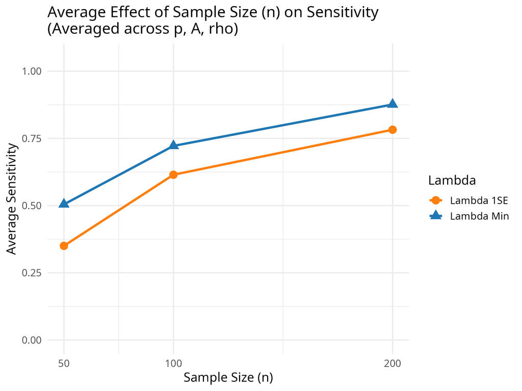

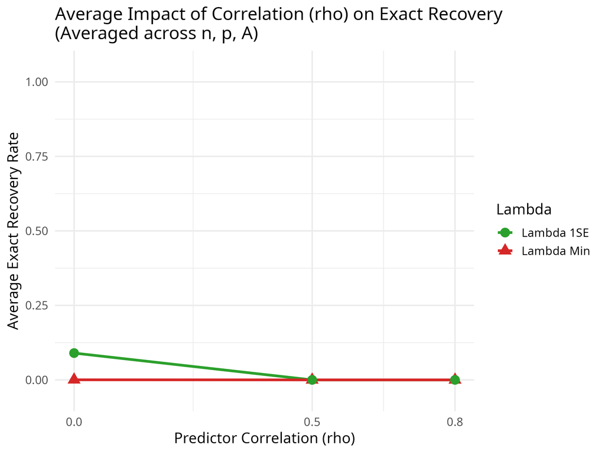

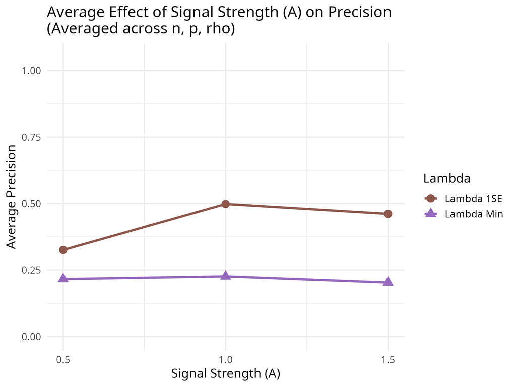

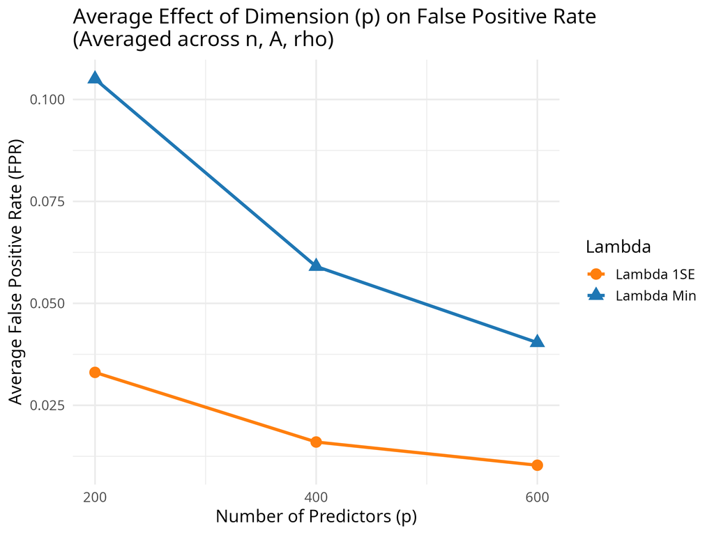

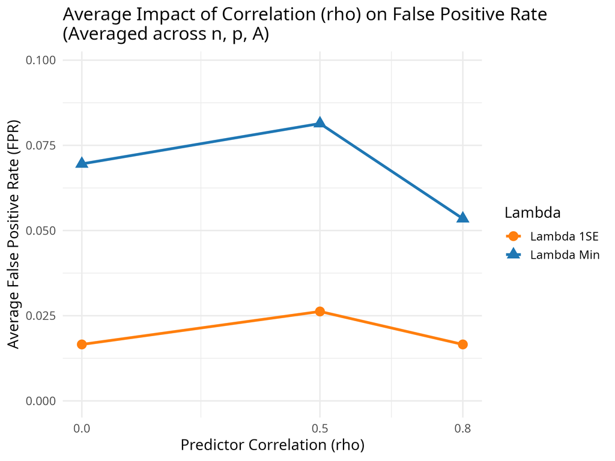

The global averages across every setting put the two tuning rules side by side:

```r
library(knitr)
comparison_table <- df %>%
  summarize(
    `Lambda Min` = c(
      mean(min_sensitivity, na.rm = TRUE),
      mean(min_fpr, na.rm = TRUE),
      mean(min_precision, na.rm = TRUE),
      mean(min_exact_recovery, na.rm = TRUE),
      mean(min_mse, na.rm = TRUE)
    ),
    `Lambda 1SE` = c(
      mean(lse_sensitivity, na.rm = TRUE),
      mean(lse_fpr, na.rm = TRUE),
      mean(lse_precision, na.rm = TRUE),
      mean(lse_exact_recovery, na.rm = TRUE),
      mean(lse_mse, na.rm = TRUE)
    )
  ) %>%
  mutate(Metric = c("Sensitivity",
                    "False Positive Rate (FPR)",
                    "Precision",
                    "Exact Recovery Rate",
                    "Test MSE")) %>%
  select(Metric, `Lambda Min`, `Lambda 1SE`) %>%
  mutate(across(where(is.numeric), ~round(., 3)))

kable(comparison_table, caption = "Global Average Comparison: Lambda Min vs Lambda 1SE")
```

Global Average Comparison: Lambda Min vs Lambda 1SE

| Metric | Lambda Min | Lambda 1SE |
| --- | --- | --- |
| Sensitivity | 0.701 | 0.582 |
| False Positive Rate (FPR) | 0.068 | 0.020 |
| Precision | 0.215 | 0.428 |
| Exact Recovery Rate | 0.000 | 0.030 |
| Test MSE | 1.858 | 2.015 |

# Takeaway